# Naive Bayes

Lizzy Presland

February 23, 2019

## A Human Evaluation of Spam vs Ham

(For Q1)

Looking at the examples in the assignment introduction, there appears to be a few distinguishing characteristics of spam:

- Use of all-caps words (eg “FREE”, “GO”, “MUSIC”)
- Use of numerals / numeric digits
- Mention of words, phrases and symbols related to money (specifically “free”, the English pound sign, “gift”, “win”, “congratulations”)
- Use of second-person addressing (though this is not uncommon in ham messages; it is an interesting characteristic in the provided examples)

## Import and Explore the Data

```r
# Q2
sms_raw <- read.csv("sms_spam.csv", header=TRUE)
# Q3
str(sms_raw)
```

```
## 'data.frame':    5559 obs. of  2 variables:
##  $ type: Factor w/ 2 levels "ham","spam": 1 1 1 2 2 1 1 1 2 1 ...
##  $ text: Factor w/ 5156 levels " #  in mca. But not conform.",..: 1651 2566 257 626 3308 190 357 3392 2726 1079 ...
```

```r
summary(sms_raw)
```

```
##    type
##  ham :4812
##  spam: 747
##
##
##
##
##
##                                                                                                                                                     text
##  Sorry, I'll call later                                                                                                                               :  30
##  I cant pick the phone right now. Pls send a message                                                                                                  :  12
##  Ok...                                                                                                                                                :  10
##  7 wonders in My WORLD 7th You 6th Ur style 5th Ur smile 4th Ur Personality 3rd Ur Nature 2nd Ur SMS and 1st Ur Lovely Friendship... good morning dear:   4
##  Ok                                                                                                                                                   :   4
##  Ok.                                                                                                                                                  :   4
##  (Other)                                                                                                                                              :5495
```

(For Q4): The target variable is the first column, which R loads as a **two-level factor** (“spam” and “ham”).

```r
# Q5
sms_raw$type <- as.factor(sms_raw$type)
table(sms_raw$type)
```

```
##
##  ham spam
## 4812  747
```

## Clean and Standardize the Data

```r
# Q6
library(tm)
sms_corpus <- Corpus(VectorSource(sms_raw$text))
# Q7
print(sms_corpus)
```

```
## <<SimpleCorpus>>
## Metadata:  corpus specific: 1, document level (indexed): 0
## Content:  documents: 5559
```

There are 5559 documents in the corpus.

Some experimenting with the various ways to view corpus data:

```r
inspect(sms_corpus[1:3])
```

```
## <<SimpleCorpus>>
## Metadata:  corpus specific: 1, document level (indexed): 0
## Content:  documents: 3
##
## [1] Hope you are having a good week. Just checking in
## [2] K..give back my thanks.
## [3] Am also doing in cbe only. But have to pay.
```

```r
# Q8
extract_text <- function(arg){as.character(arg)}
first_three_docs <- lapply(sms_corpus[1:3], extract_text)
first_three_docs
```

```
## [[1]]
## [1] "Hope you are having a good week. Just checking in"
##
## [[2]]
## [1] "K..give back my thanks."
##
## [[3]]
## [1] "Am also doing in cbe only. But have to pay."
```

We will now clean and standardize the corpus per the assignment specifications.

```r
corpus_clean <- tm_map(sms_corpus, tolower)
# Q9: original text
first_three_docs[[1]]
```

```
## [1] "Hope you are having a good week. Just checking in"
```

```r
# Q9: remapped text
as.character(corpus_clean[[1]])
```

```
## [1] "hope you are having a good week. just checking in"
```

The above blocks adjusted all uppercase letters to lowercase (to establish a better baseline for word equivalencies). We will also make the following adjustments:

- Remove all numeric digits from the corpus (Q10)
- Remove all “stop words” (such as “to”, “and”, “but”, etc)
- Remove all punctuation (Q11)
- Stemming all similar words (eg replace “learned”, “learning”, “learns”, etc with “learn”)
- Remove additional whitespace

```r
# Q10
corpus_clean <- tm_map(corpus_clean, removeNumbers)
corpus_clean <- tm_map(corpus_clean, removeWords, stopwords())
# Q11
corpus_clean <- tm_map(corpus_clean, removePunctuation)
library(SnowballC)
corpus_clean <- tm_map(corpus_clean, stemDocument)
corpus_clean <- tm_map(corpus_clean, stripWhitespace)
```

Here’s a view of the 5th document before and after standardization:

```r
# Q12: before standardization
as.character(sms_corpus[[5]])
```

```
## [1] "okmail: Dear Dave this is your final notice to collect your 4* Tenerife Holiday or #5000 CASH award! Call 09061743806 from landline. TCs SAE Box326 CW25WX 150ppm"
```

```r
# Q12: after standardization
as.character(corpus_clean[[5]])
```

```
## [1] "okmail dear dave final notic collect tenerif holiday cash award call landlin tcs sae box cwwx ppm"
```

## Creating the “Bag’o’Words”

```r
# having issues with the call below:
# error is: "Line 102: Error in `[.simple_triplet_matrix`(object, !nas) : Logical vector subscripting disabled for this object. Calls: <Anonymous> ... [.DocumentTermMatrix -> NextMethod -> [.simple_triplet_matrix Execution halted"
sms_dtm <- DocumentTermMatrix(corpus_clean)
# note: error was due to trying to call summary(sms_dtm)
```

## Create Training and Test Datasets

```r
# Q13
sms_dtm_train <- sms_dtm[1:4447]
sms_dtm_test <- sms_dtm[4448:5559]
# Q14
sms_train_labels <- sms_raw$type[1:4447]
sms_test_labels <- sms_raw$type[4448:5559]
```

Confirm that the “spam” and “ham” items are evenly (ish) distributed between the training and test data:

```r
prop.table(table(sms_train_labels))
```

```
## sms_train_labels
##       ham      spam
## 0.8657522 0.1342478
```

```r
prop.table(table(sms_test_labels))
```

```
## sms_test_labels
##       ham      spam
## 0.8651079 0.1348921
```

Looks pretty good, so let’s keep going!

## Word Clouds

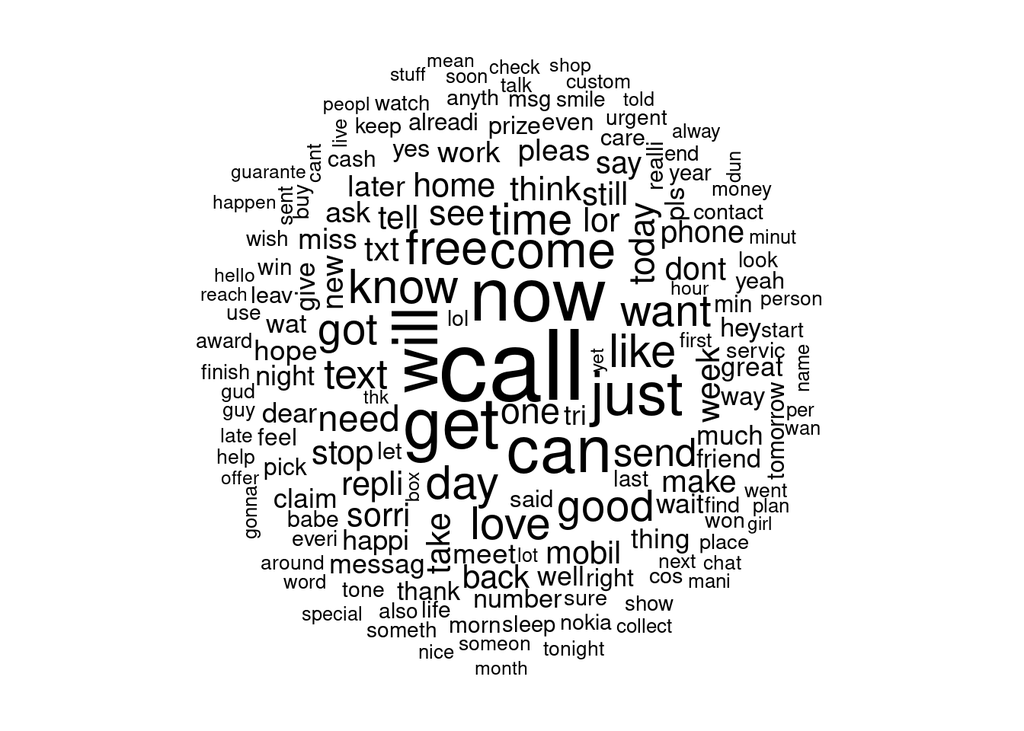

```r
# Q15
library(wordcloud)
wordcloud(corpus_clean, min.freq=50, random.order=FALSE)
```

Visualize spam & ham wordclouds.

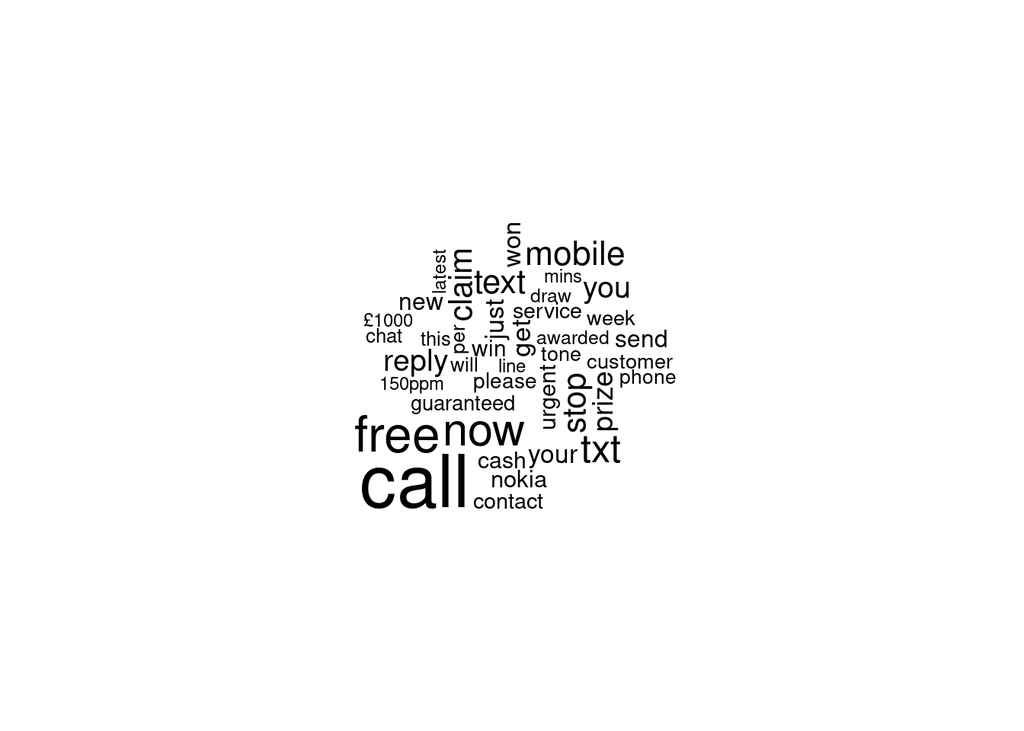

```r
spam <- subset(sms_raw, type=="spam")
ham <- subset(sms_raw, type=="ham")
wordcloud(spam$text, max.words = 40, scal=c(3, 0.5))
```

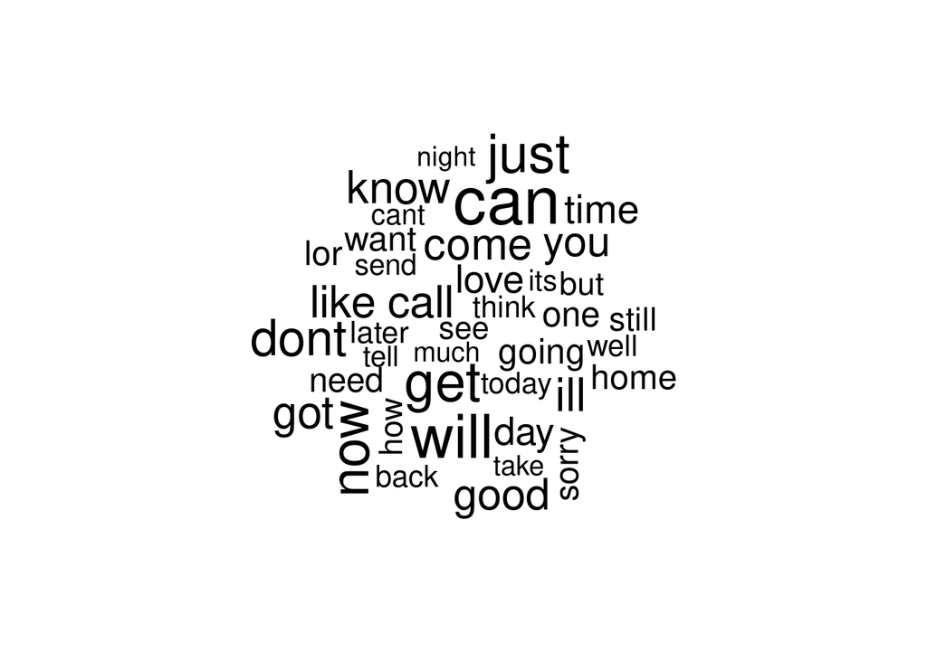

```r
wordcloud(ham$text, max.words = 40, scal=c(3, 0.5))
```

Regarding Question 16: The “spam” cloud heavily favors certain words, whereas the “ham” cloud has a more uniform distribution of the wordcloud’s word size (which presumably corresponds to the frequency of the word’s occurence).

## Indicator Features for Frequent Words

```r
# ERROR
# Quitting from lines 152-156 (nb.rmd)
# Error: $ operator is invalid for atomic vectors
# Execution halted

# ERROR IS FROM THE LINE BELOW
# sms_freq_words <- findFreqTerms(sms_dtm_train, 5)
# Q17
# str(sms_freq_words)
# summary(sms_freq_words)

sms_dtm
```

```
## <<DocumentTermMatrix (documents: 5559, terms: 6572)>>
## Non-/sparse entries: 42176/36491572
## Sparsity           : 100%
## Maximal term length: 40
## Weighting          : term frequency (tf)
```